# Statistiek I - Lab session 4

Robert van Timmeren (s4535553)

Generated on: Tue Mar 02 22:24:39 2021

# 1 Exercise 1

```r
#Downloading and loading data
download.file('http://www.let.rug.nl/wieling/Statistiek-I/dat.rda','dat.rda')
load('dat.rda',verbose=T)
```

```
## Loading objects:
##   dat
```

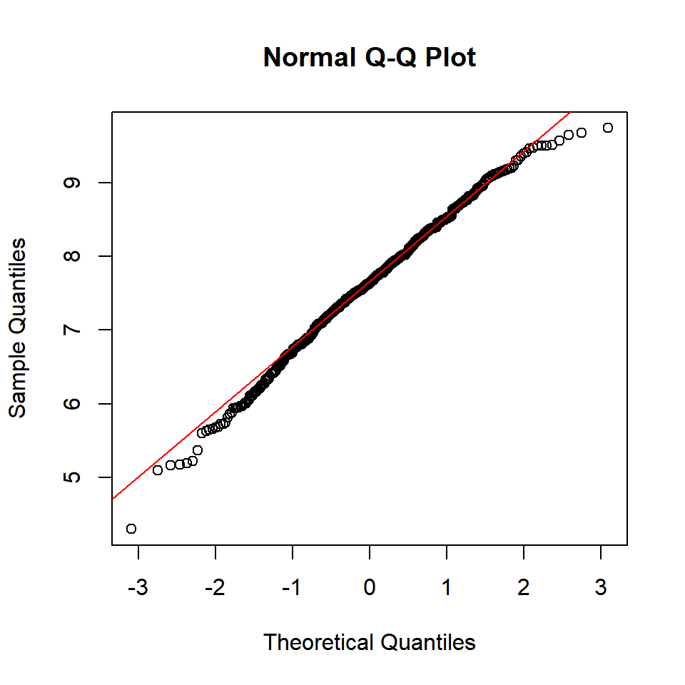

```r
#Q-Q Plot to verify the English scores data is normally distributed
qqnorm(dat$english_score)
qqline(dat$english_score, col = 'red')
```

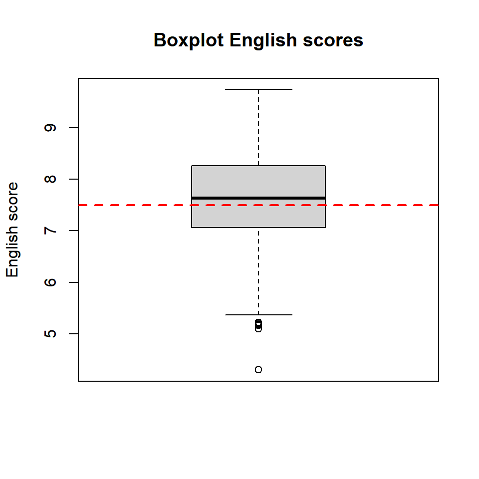

```r
#Boxplot to investigate the data as well and visualize it
boxplot(dat$english_score, main = 'Boxplot English scores', ylab = "English score")
abline(h=7.5, lty = 2, lwd = 2, col = 'red')
```

```r
#Conducting the t-test
t.test(dat$english_score, alternative="greater", mu=7.5)
```

```
##
##  One Sample t-test
##
## data:  dat$english_score
## t = 2.9216, df = 501, p-value = 0.00182
## alternative hypothesis: true mean is greater than 7.5
## 95 percent confidence interval:
##  7.552421      Inf
## sample estimates:
## mean of x
##  7.620241
```

```r
#Calculating Cohen's d
#Sample mean (m) - mu (u) / std deviation
#7.62 - 7.5 / 0.92
(mean(dat$english_score) - 7.5) / sd(dat$english_score)
```

```
## [1] 0.1303993
```

# 2 Exercise 2

```r
#Conducting the t-test
t.test(dat$english_score, alternative="two.sided", mu=7.5)
```

```
##
##  One Sample t-test
##
## data:  dat$english_score
## t = 2.9216, df = 501, p-value = 0.003639
## alternative hypothesis: true mean is not equal to 7.5
## 95 percent confidence interval:
##  7.539383 7.701100
## sample estimates:
## mean of x
##  7.620241
```

```r
#Calculating Cohen's d
#Sample mean (m) - mu (u) / std deviation
#7.62 - 7.5 / 0.92
(mean(dat$english_score) - 7.5) / sd(dat$english_score)
```

```
## [1] 0.1303993
```

I tested whether the average English scores of students following Statistiek 1 was significantly different from 7.5. Our hypotheses were: **$H_0$: Average English score = 7.5** and **$H_a$: Average English score $\neq$ 7.5** We obtained the English scores in a **sample of 502** students of the Statistiek 1 course via an online questionnaire. Since σ is unknown and we wish to compare the sample mean with a fixed value, we conducted a **single samples t-test** after verifying that the **assumptions for the test were met** (normally distributed and more than 30 values - see Q-Q plot and boxplot exercise 1). The mean of the English scores in the sample was 7.62, and we want to compare it with 7.5. The **effect size was negligible** (Cohen’s d: 0.13), and it reached significance at **$\alpha$-level 0.05: t(501) = 2.9216, p = 0.003639**. We therefore **reject the null hypothesis and accept the alternative hypothesis** that the English scores of students following Statistiek 1 is significantly different from 7.5, because 0.003639 is lower than 0.05.

# 3 Exercise 3

```r
par(mfrow=c(1,2))
#Investigating dataset for men/women
table(dat$gender)
```

```
##
##   F   M
## 347 155
```

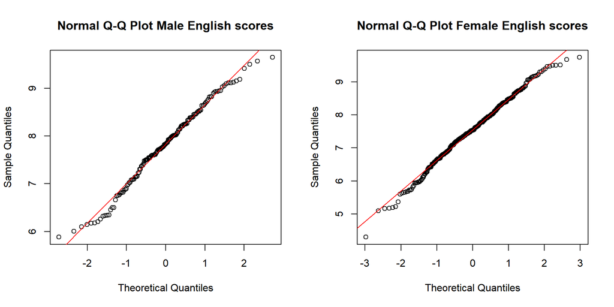

```r
#Q-Q plot for male English scores
qqnorm(dat[dat$gender == "M", ]$english_score, main = 'Normal Q-Q Plot Male English scores')
qqline(dat[dat$gender == "M", ]$english_score, col = 'red')

#Q-Q plot for female English scores
qqnorm(dat[dat$gender == "F", ]$english_score, main = 'Normal Q-Q Plot Female English scores')
qqline(dat[dat$gender == "F", ]$english_score, col = 'red')
```

```r
#Visualizing data
dat$gender = relevel(dat$gender, 'M')
boxplot(english_score ~ gender, data=dat, main = 'Boxplot Male and Female English scores')

#Conducting t-test
t.test(english_score ~ gender, data=dat, alternative="two.sided")
```

```
##
##  Welch Two Sample t-test
##
## data:  english_score by gender
## t = 3.3075, df = 332.23, p-value = 0.001044
## alternative hypothesis: true difference in means is not equal to 0
## 95 percent confidence interval:
##  0.1128939 0.4442577
## sample estimates:
## mean in group M mean in group F
##        7.812803        7.534227
```

```r
#Calculating Cohen's d
library(effsize)
cohen.d(english_score ~ gender, data = dat)
```

```
##
## Cohen's d
##
## d estimate: 0.3047977 (small)
## 95 percent confidence interval:
##     lower     upper
## 0.1140479 0.4955475
```

[figure not shown]

I tested whether the average English scores of male students following Statistiek 1 was significantly different from female students following Statistiek 1. Our hypotheses were: **$H_0$: μm = μf** and **$H_a$: μm $\neq$ μf** We obtained the English scores in a **sample of 502** students of the Statistiek 1 course via an online questionnaire, where 347 respondents were female and 155 were male. Since σ is unknown and we wish to compare the two sample means with each other, we conducted an **independent samples t-test** after verifying that the **assumptions for the test were met** (normally distributed and more than 30 values - see Q-Q plots male/female). The mean of the English scores for male respondents in the sample was 7.81 and for the female respondents it was 7.53. The **effect size was small** (Cohen’s d: 0.3047977), and it reached significance at **$\alpha$-level 0.05: t(332.23) = 3.3075, p = 0.001044**. We therefore **reject the null hypothesis and accept the alternative hypothesis** that the English scores of male students and female students following Statistiek 1 are significantly different from each other, because 0.001044 is lower than 0.05.